# How Do Casual Cyclistic Riders Differ from Members?

Lee Crowther

2022-07-16

## Introduction

This case study analyzes bike-share data from the fictional company Cyclistic to discover differences between riders with an annual membership (“members”) and riders who purchase single-use or day passes (“casual riders”), with the aim of discovering insights that can help Cyclistic convert casual riders into members.

### Related pages

- This report provides a detailed look at the analysis process. To view a summary report, visit [this page](https://htmlpreview.github.io/?https://github.com/crowtherln/cyclistic/blob/main/casual-riders-vs-members_summary.html).
- To view the R Markdown file that produced this report, visit [this page](https://github.com/crowtherln/cyclistic/blob/main/casual-riders-vs-members.Rmd).
- To view the raw html for this report, visit [this page](https://github.com/crowtherln/cyclistic/blob/main/casual-riders-vs-members.html).
- To view the R Markdown file that produced the summary report, visit [this page](https://github.com/crowtherln/cyclistic/blob/main/casual-riders-vs-members_summary.Rmd).

### Credits

The task was provided by Google as part of the Coursera course “[Google Data Analytics Capstone: Complete a Case Study](https://www.coursera.org/learn/google-data-analytics-capstone),” part of the [Google Data Analytics Professional Certificate](https://www.coursera.org/professional-certificates/google-data-analytics).

The [data](https://divvy-tripdata.s3.amazonaws.com/index.html) was provided by [Divvy](https://ride.divvybikes.com/), a real-world bike share system in the Chicago area that is owned by the [Chicago Department of Transportation](https://www.chicago.gov/city/en/depts/cdot.html) (CDOT) and managed by [Lyft, Inc.](https://www.lyft.com/), and made available under [this license](https://ride.divvybikes.com/data-license-agreement).

The R script is adapted from [this script](https://docs.google.com/document/d/1TTj5KNKf4BWvEORGm10oNbpwTRk1hamsWJGj6qRWpuI/edit), which in turn is based on “[‘Sophisticated, Clear, and Polished’: Divvy and Data Visualization](https://artscience.blog/home/divvy-dataviz-case-study),” written by Kevin Hartman.

## Setting up

### Installing packages

This program uses the tidyverse package to import and clean the data, the lubridate package for date functions, the scales package for visualization labels, the geosphere package to calculate distances, and the knitr package to format tables.

```r
library(tidyverse)
library(lubridate)
library(scales)
library(geosphere)
library(knitr)
```

### Reading the data

The data first needs to be downloaded from [Divvy](https://divvy-tripdata.s3.amazonaws.com/index.html). After the data has been downloaded and extracted, the CSV files can be read into R as dataframes.

```r
# Read the CSV files for the past year of Cyclistic data. In this example, the
  # dates are June 2021–May 2022.
cycl_202106 <- read_csv(
  "C:/Users/rastley/Documents/data/202106-divvy-tripdata.csv")
cycl_202107 <- read_csv(
  "C:/Users/rastley/Documents/data/202107-divvy-tripdata.csv")
cycl_202108 <- read_csv(
  "C:/Users/rastley/Documents/data/202108-divvy-tripdata.csv")
cycl_202109 <- read_csv(
  "C:/Users/rastley/Documents/data/202109-divvy-tripdata.csv")
cycl_202110 <- read_csv(
  "C:/Users/rastley/Documents/data/202110-divvy-tripdata.csv")
cycl_202111 <- read_csv(
  "C:/Users/rastley/Documents/data/202111-divvy-tripdata.csv")
cycl_202112 <- read_csv(
  "C:/Users/rastley/Documents/data/202112-divvy-tripdata.csv")
cycl_202201 <- read_csv(
  "C:/Users/rastley/Documents/data/202201-divvy-tripdata.csv")
cycl_202202 <- read_csv(
  "C:/Users/rastley/Documents/data/202202-divvy-tripdata.csv")
cycl_202203 <- read_csv(
  "C:/Users/rastley/Documents/data/202203-divvy-tripdata.csv")
cycl_202204 <- read_csv(
  "C:/Users/rastley/Documents/data/202204-divvy-tripdata.csv")
cycl_202205 <- read_csv(
  "C:/Users/rastley/Documents/data/202205-divvy-tripdata.csv")
```

## Data cleaning and exploration

### Combining the data into a single dataframe

Before combining the source data into a single dataframe, we need to make sure the column names are the same in each source dataframe.

```r
colnames(cycl_202106)
```

```
##  [1] "ride_id"            "rideable_type"      "started_at"
##  [4] "ended_at"           "start_station_name" "start_station_id"
##  [7] "end_station_name"   "end_station_id"     "start_lat"
## [10] "start_lng"          "end_lat"            "end_lng"
## [13] "member_casual"
```

```r
colnames(cycl_202107)
```

```
##  [1] "ride_id"            "rideable_type"      "started_at"
##  [4] "ended_at"           "start_station_name" "start_station_id"
##  [7] "end_station_name"   "end_station_id"     "start_lat"
## [10] "start_lng"          "end_lat"            "end_lng"
## [13] "member_casual"
```

```r
colnames(cycl_202108)
```

```
##  [1] "ride_id"            "rideable_type"      "started_at"
##  [4] "ended_at"           "start_station_name" "start_station_id"
##  [7] "end_station_name"   "end_station_id"     "start_lat"
## [10] "start_lng"          "end_lat"            "end_lng"
## [13] "member_casual"
```

```r
colnames(cycl_202109)
```

```
##  [1] "ride_id"            "rideable_type"      "started_at"
##  [4] "ended_at"           "start_station_name" "start_station_id"
##  [7] "end_station_name"   "end_station_id"     "start_lat"
## [10] "start_lng"          "end_lat"            "end_lng"
## [13] "member_casual"
```

```r
colnames(cycl_202110)
```

```
##  [1] "ride_id"            "rideable_type"      "started_at"
##  [4] "ended_at"           "start_station_name" "start_station_id"
##  [7] "end_station_name"   "end_station_id"     "start_lat"
## [10] "start_lng"          "end_lat"            "end_lng"
## [13] "member_casual"
```

```r
colnames(cycl_202111)
```

```
##  [1] "ride_id"            "rideable_type"      "started_at"
##  [4] "ended_at"           "start_station_name" "start_station_id"
##  [7] "end_station_name"   "end_station_id"     "start_lat"
## [10] "start_lng"          "end_lat"            "end_lng"
## [13] "member_casual"
```

```r
colnames(cycl_202112)
```

```
##  [1] "ride_id"            "rideable_type"      "started_at"
##  [4] "ended_at"           "start_station_name" "start_station_id"
##  [7] "end_station_name"   "end_station_id"     "start_lat"
## [10] "start_lng"          "end_lat"            "end_lng"
## [13] "member_casual"
```

```r
colnames(cycl_202201)
```

```
##  [1] "ride_id"            "rideable_type"      "started_at"
##  [4] "ended_at"           "start_station_name" "start_station_id"
##  [7] "end_station_name"   "end_station_id"     "start_lat"
## [10] "start_lng"          "end_lat"            "end_lng"
## [13] "member_casual"
```

```r
colnames(cycl_202202)
```

```
##  [1] "ride_id"            "rideable_type"      "started_at"
##  [4] "ended_at"           "start_station_name" "start_station_id"
##  [7] "end_station_name"   "end_station_id"     "start_lat"
## [10] "start_lng"          "end_lat"            "end_lng"
## [13] "member_casual"
```

```r
colnames(cycl_202203)
```

```
##  [1] "ride_id"            "rideable_type"      "started_at"
##  [4] "ended_at"           "start_station_name" "start_station_id"
##  [7] "end_station_name"   "end_station_id"     "start_lat"
## [10] "start_lng"          "end_lat"            "end_lng"
## [13] "member_casual"
```

```r
colnames(cycl_202204)
```

```
##  [1] "ride_id"            "rideable_type"      "started_at"
##  [4] "ended_at"           "start_station_name" "start_station_id"
##  [7] "end_station_name"   "end_station_id"     "start_lat"
## [10] "start_lng"          "end_lat"            "end_lng"
## [13] "member_casual"
```

```r
colnames(cycl_202205)
```

```
##  [1] "ride_id"            "rideable_type"      "started_at"
##  [4] "ended_at"           "start_station_name" "start_station_id"
##  [7] "end_station_name"   "end_station_id"     "start_lat"
## [10] "start_lng"          "end_lat"            "end_lng"
## [13] "member_casual"
```

Each dataframe has the same column names. Now we’ll inspect the dataframe structures to see if anything looks off.

```r
str(cycl_202106)
```

```
## spec_tbl_df [729,595 × 13] (S3: spec_tbl_df/tbl_df/tbl/data.frame)
##  $ ride_id           : chr [1:729595] "99FEC93BA843FB20" "06048DCFC8520CAF" "9598066F68045DF2" "B03C0FE48C412214" ...
##  $ rideable_type     : chr [1:729595] "electric_bike" "electric_bike" "electric_bike" "electric_bike" ...
##  $ started_at        : POSIXct[1:729595], format: "2021-06-13 14:31:28" "2021-06-04 11:18:02" ...
##  $ ended_at          : POSIXct[1:729595], format: "2021-06-13 14:34:11" "2021-06-04 11:24:19" ...
##  $ start_station_name: chr [1:729595] NA NA NA NA ...
##  $ start_station_id  : chr [1:729595] NA NA NA NA ...
##  $ end_station_name  : chr [1:729595] NA NA NA NA ...
##  $ end_station_id    : chr [1:729595] NA NA NA NA ...
##  $ start_lat         : num [1:729595] 41.8 41.8 41.8 41.8 41.8 ...
##  $ start_lng         : num [1:729595] -87.6 -87.6 -87.6 -87.6 -87.6 ...
##  $ end_lat           : num [1:729595] 41.8 41.8 41.8 41.8 41.8 ...
##  $ end_lng           : num [1:729595] -87.6 -87.6 -87.6 -87.6 -87.6 ...
##  $ member_casual     : chr [1:729595] "member" "member" "member" "member" ...
##  - attr(*, "spec")=
##   .. cols(
##   ..   ride_id = col_character(),
##   ..   rideable_type = col_character(),
##   ..   started_at = col_datetime(format = ""),
##   ..   ended_at = col_datetime(format = ""),
##   ..   start_station_name = col_character(),
##   ..   start_station_id = col_character(),
##   ..   end_station_name = col_character(),
##   ..   end_station_id = col_character(),
##   ..   start_lat = col_double(),
##   ..   start_lng = col_double(),
##   ..   end_lat = col_double(),
##   ..   end_lng = col_double(),
##   ..   member_casual = col_character()
##   .. )
##  - attr(*, "problems")=<externalptr>
```

```r
str(cycl_202107)
```

```
## spec_tbl_df [822,410 × 13] (S3: spec_tbl_df/tbl_df/tbl/data.frame)
##  $ ride_id           : chr [1:822410] "0A1B623926EF4E16" "B2D5583A5A5E76EE" "6F264597DDBF427A" "379B58EAB20E8AA5" ...
##  $ rideable_type     : chr [1:822410] "docked_bike" "classic_bike" "classic_bike" "classic_bike" ...
##  $ started_at        : POSIXct[1:822410], format: "2021-07-02 14:44:36" "2021-07-07 16:57:42" ...
##  $ ended_at          : POSIXct[1:822410], format: "2021-07-02 15:19:58" "2021-07-07 17:16:09" ...
##  $ start_station_name: chr [1:822410] "Michigan Ave & Washington St" "California Ave & Cortez St" "Wabash Ave & 16th St" "California Ave & Cortez St" ...
##  $ start_station_id  : chr [1:822410] "13001" "17660" "SL-012" "17660" ...
##  $ end_station_name  : chr [1:822410] "Halsted St & North Branch St" "Wood St & Hubbard St" "Rush St & Hubbard St" "Carpenter St & Huron St" ...
##  $ end_station_id    : chr [1:822410] "KA1504000117" "13432" "KA1503000044" "13196" ...
##  $ start_lat         : num [1:822410] 41.9 41.9 41.9 41.9 41.9 ...
##  $ start_lng         : num [1:822410] -87.6 -87.7 -87.6 -87.7 -87.7 ...
##  $ end_lat           : num [1:822410] 41.9 41.9 41.9 41.9 41.9 ...
##  $ end_lng           : num [1:822410] -87.6 -87.7 -87.6 -87.7 -87.7 ...
##  $ member_casual     : chr [1:822410] "casual" "casual" "member" "member" ...
##  - attr(*, "spec")=
##   .. cols(
##   ..   ride_id = col_character(),
##   ..   rideable_type = col_character(),
##   ..   started_at = col_datetime(format = ""),
##   ..   ended_at = col_datetime(format = ""),
##   ..   start_station_name = col_character(),
##   ..   start_station_id = col_character(),
##   ..   end_station_name = col_character(),
##   ..   end_station_id = col_character(),
##   ..   start_lat = col_double(),
##   ..   start_lng = col_double(),
##   ..   end_lat = col_double(),
##   ..   end_lng = col_double(),
##   ..   member_casual = col_character()
##   .. )
##  - attr(*, "problems")=<externalptr>
```

```r
str(cycl_202108)
```

```
## spec_tbl_df [804,352 × 13] (S3: spec_tbl_df/tbl_df/tbl/data.frame)
##  $ ride_id           : chr [1:804352] "99103BB87CC6C1BB" "EAFCCCFB0A3FC5A1" "9EF4F46C57AD234D" "5834D3208BFAF1DA" ...
##  $ rideable_type     : chr [1:804352] "electric_bike" "electric_bike" "electric_bike" "electric_bike" ...
##  $ started_at        : POSIXct[1:804352], format: "2021-08-10 17:15:49" "2021-08-10 17:23:14" ...
##  $ ended_at          : POSIXct[1:804352], format: "2021-08-10 17:22:44" "2021-08-10 17:39:24" ...
##  $ start_station_name: chr [1:804352] NA NA NA NA ...
##  $ start_station_id  : chr [1:804352] NA NA NA NA ...
##  $ end_station_name  : chr [1:804352] NA NA NA NA ...
##  $ end_station_id    : chr [1:804352] NA NA NA NA ...
##  $ start_lat         : num [1:804352] 41.8 41.8 42 42 41.8 ...
##  $ start_lng         : num [1:804352] -87.7 -87.7 -87.7 -87.7 -87.6 ...
##  $ end_lat           : num [1:804352] 41.8 41.8 42 42 41.8 ...
##  $ end_lng           : num [1:804352] -87.7 -87.6 -87.7 -87.7 -87.6 ...
##  $ member_casual     : chr [1:804352] "member" "member" "member" "member" ...
##  - attr(*, "spec")=
##   .. cols(
##   ..   ride_id = col_character(),
##   ..   rideable_type = col_character(),
##   ..   started_at = col_datetime(format = ""),
##   ..   ended_at = col_datetime(format = ""),
##   ..   start_station_name = col_character(),
##   ..   start_station_id = col_character(),
##   ..   end_station_name = col_character(),
##   ..   end_station_id = col_character(),
##   ..   start_lat = col_double(),
##   ..   start_lng = col_double(),
##   ..   end_lat = col_double(),
##   ..   end_lng = col_double(),
##   ..   member_casual = col_character()
##   .. )
##  - attr(*, "problems")=<externalptr>
```

```r
str(cycl_202109)
```

```
## spec_tbl_df [756,147 × 13] (S3: spec_tbl_df/tbl_df/tbl/data.frame)
##  $ ride_id           : chr [1:756147] "9DC7B962304CBFD8" "F930E2C6872D6B32" "6EF72137900BB910" "78D1DE133B3DBF55" ...
##  $ rideable_type     : chr [1:756147] "electric_bike" "electric_bike" "electric_bike" "electric_bike" ...
##  $ started_at        : POSIXct[1:756147], format: "2021-09-28 16:07:10" "2021-09-28 14:24:51" ...
##  $ ended_at          : POSIXct[1:756147], format: "2021-09-28 16:09:54" "2021-09-28 14:40:05" ...
##  $ start_station_name: chr [1:756147] NA NA NA NA ...
##  $ start_station_id  : chr [1:756147] NA NA NA NA ...
##  $ end_station_name  : chr [1:756147] NA NA NA NA ...
##  $ end_station_id    : chr [1:756147] NA NA NA NA ...
##  $ start_lat         : num [1:756147] 41.9 41.9 41.8 41.8 41.9 ...
##  $ start_lng         : num [1:756147] -87.7 -87.6 -87.7 -87.7 -87.7 ...
##  $ end_lat           : num [1:756147] 41.9 42 41.8 41.8 41.9 ...
##  $ end_lng           : num [1:756147] -87.7 -87.7 -87.7 -87.7 -87.7 ...
##  $ member_casual     : chr [1:756147] "casual" "casual" "casual" "casual" ...
##  - attr(*, "spec")=
##   .. cols(
##   ..   ride_id = col_character(),
##   ..   rideable_type = col_character(),
##   ..   started_at = col_datetime(format = ""),
##   ..   ended_at = col_datetime(format = ""),
##   ..   start_station_name = col_character(),
##   ..   start_station_id = col_character(),
##   ..   end_station_name = col_character(),
##   ..   end_station_id = col_character(),
##   ..   start_lat = col_double(),
##   ..   start_lng = col_double(),
##   ..   end_lat = col_double(),
##   ..   end_lng = col_double(),
##   ..   member_casual = col_character()
##   .. )
##  - attr(*, "problems")=<externalptr>
```

```r
str(cycl_202110)
```

```
## spec_tbl_df [631,226 × 13] (S3: spec_tbl_df/tbl_df/tbl/data.frame)
##  $ ride_id           : chr [1:631226] "620BC6107255BF4C" "4471C70731AB2E45" "26CA69D43D15EE14" "362947F0437E1514" ...
##  $ rideable_type     : chr [1:631226] "electric_bike" "electric_bike" "electric_bike" "electric_bike" ...
##  $ started_at        : POSIXct[1:631226], format: "2021-10-22 12:46:42" "2021-10-21 09:12:37" ...
##  $ ended_at          : POSIXct[1:631226], format: "2021-10-22 12:49:50" "2021-10-21 09:14:14" ...
##  $ start_station_name: chr [1:631226] "Kingsbury St & Kinzie St" NA NA NA ...
##  $ start_station_id  : chr [1:631226] "KA1503000043" NA NA NA ...
##  $ end_station_name  : chr [1:631226] NA NA NA NA ...
##  $ end_station_id    : chr [1:631226] NA NA NA NA ...
##  $ start_lat         : num [1:631226] 41.9 41.9 41.9 41.9 41.9 ...
##  $ start_lng         : num [1:631226] -87.6 -87.7 -87.7 -87.7 -87.7 ...
##  $ end_lat           : num [1:631226] 41.9 41.9 41.9 41.9 41.9 ...
##  $ end_lng           : num [1:631226] -87.6 -87.7 -87.7 -87.7 -87.7 ...
##  $ member_casual     : chr [1:631226] "member" "member" "member" "member" ...
##  - attr(*, "spec")=
##   .. cols(
##   ..   ride_id = col_character(),
##   ..   rideable_type = col_character(),
##   ..   started_at = col_datetime(format = ""),
##   ..   ended_at = col_datetime(format = ""),
##   ..   start_station_name = col_character(),
##   ..   start_station_id = col_character(),
##   ..   end_station_name = col_character(),
##   ..   end_station_id = col_character(),
##   ..   start_lat = col_double(),
##   ..   start_lng = col_double(),
##   ..   end_lat = col_double(),
##   ..   end_lng = col_double(),
##   ..   member_casual = col_character()
##   .. )
##  - attr(*, "problems")=<externalptr>
```

```r
str(cycl_202111)
```

```
## spec_tbl_df [359,978 × 13] (S3: spec_tbl_df/tbl_df/tbl/data.frame)
##  $ ride_id           : chr [1:359978] "7C00A93E10556E47" "90854840DFD508BA" "0A7D10CDD144061C" "2F3BE33085BCFF02" ...
##  $ rideable_type     : chr [1:359978] "electric_bike" "electric_bike" "electric_bike" "electric_bike" ...
##  $ started_at        : POSIXct[1:359978], format: "2021-11-27 13:27:38" "2021-11-27 13:38:25" ...
##  $ ended_at          : POSIXct[1:359978], format: "2021-11-27 13:46:38" "2021-11-27 13:56:10" ...
##  $ start_station_name: chr [1:359978] NA NA NA NA ...
##  $ start_station_id  : chr [1:359978] NA NA NA NA ...
##  $ end_station_name  : chr [1:359978] NA NA NA NA ...
##  $ end_station_id    : chr [1:359978] NA NA NA NA ...
##  $ start_lat         : num [1:359978] 41.9 42 42 41.9 41.9 ...
##  $ start_lng         : num [1:359978] -87.7 -87.7 -87.7 -87.8 -87.6 ...
##  $ end_lat           : num [1:359978] 42 41.9 42 41.9 41.9 ...
##  $ end_lng           : num [1:359978] -87.7 -87.7 -87.7 -87.8 -87.6 ...
##  $ member_casual     : chr [1:359978] "casual" "casual" "casual" "casual" ...
##  - attr(*, "spec")=
##   .. cols(
##   ..   ride_id = col_character(),
##   ..   rideable_type = col_character(),
##   ..   started_at = col_datetime(format = ""),
##   ..   ended_at = col_datetime(format = ""),
##   ..   start_station_name = col_character(),
##   ..   start_station_id = col_character(),
##   ..   end_station_name = col_character(),
##   ..   end_station_id = col_character(),
##   ..   start_lat = col_double(),
##   ..   start_lng = col_double(),
##   ..   end_lat = col_double(),
##   ..   end_lng = col_double(),
##   ..   member_casual = col_character()
##   .. )
##  - attr(*, "problems")=<externalptr>
```

```r
str(cycl_202112)
```

```
## spec_tbl_df [247,540 × 13] (S3: spec_tbl_df/tbl_df/tbl/data.frame)
##  $ ride_id           : chr [1:247540] "46F8167220E4431F" "73A77762838B32FD" "4CF42452054F59C5" "3278BA87BF698339" ...
##  $ rideable_type     : chr [1:247540] "electric_bike" "electric_bike" "electric_bike" "classic_bike" ...
##  $ started_at        : POSIXct[1:247540], format: "2021-12-07 15:06:07" "2021-12-11 03:43:29" ...
##  $ ended_at          : POSIXct[1:247540], format: "2021-12-07 15:13:42" "2021-12-11 04:10:23" ...
##  $ start_station_name: chr [1:247540] "Laflin St & Cullerton St" "LaSalle Dr & Huron St" "Halsted St & North Branch St" "Halsted St & North Branch St" ...
##  $ start_station_id  : chr [1:247540] "13307" "KP1705001026" "KA1504000117" "KA1504000117" ...
##  $ end_station_name  : chr [1:247540] "Morgan St & Polk St" "Clarendon Ave & Leland Ave" "Broadway & Barry Ave" "LaSalle Dr & Huron St" ...
##  $ end_station_id    : chr [1:247540] "TA1307000130" "TA1307000119" "13137" "KP1705001026" ...
##  $ start_lat         : num [1:247540] 41.9 41.9 41.9 41.9 41.9 ...
##  $ start_lng         : num [1:247540] -87.7 -87.6 -87.6 -87.6 -87.7 ...
##  $ end_lat           : num [1:247540] 41.9 42 41.9 41.9 41.9 ...
##  $ end_lng           : num [1:247540] -87.7 -87.7 -87.6 -87.6 -87.6 ...
##  $ member_casual     : chr [1:247540] "member" "casual" "member" "member" ...
##  - attr(*, "spec")=
##   .. cols(
##   ..   ride_id = col_character(),
##   ..   rideable_type = col_character(),
##   ..   started_at = col_datetime(format = ""),
##   ..   ended_at = col_datetime(format = ""),
##   ..   start_station_name = col_character(),
##   ..   start_station_id = col_character(),
##   ..   end_station_name = col_character(),
##   ..   end_station_id = col_character(),
##   ..   start_lat = col_double(),
##   ..   start_lng = col_double(),
##   ..   end_lat = col_double(),
##   ..   end_lng = col_double(),
##   ..   member_casual = col_character()
##   .. )
##  - attr(*, "problems")=<externalptr>
```

```r
str(cycl_202201)
```

```
## spec_tbl_df [103,770 × 13] (S3: spec_tbl_df/tbl_df/tbl/data.frame)
##  $ ride_id           : chr [1:103770] "C2F7DD78E82EC875" "A6CF8980A652D272" "BD0F91DFF741C66D" "CBB80ED419105406" ...
##  $ rideable_type     : chr [1:103770] "electric_bike" "electric_bike" "classic_bike" "classic_bike" ...
##  $ started_at        : POSIXct[1:103770], format: "2022-01-13 11:59:47" "2022-01-10 08:41:56" ...
##  $ ended_at          : POSIXct[1:103770], format: "2022-01-13 12:02:44" "2022-01-10 08:46:17" ...
##  $ start_station_name: chr [1:103770] "Glenwood Ave & Touhy Ave" "Glenwood Ave & Touhy Ave" "Sheffield Ave & Fullerton Ave" "Clark St & Bryn Mawr Ave" ...
##  $ start_station_id  : chr [1:103770] "525" "525" "TA1306000016" "KA1504000151" ...
##  $ end_station_name  : chr [1:103770] "Clark St & Touhy Ave" "Clark St & Touhy Ave" "Greenview Ave & Fullerton Ave" "Paulina St & Montrose Ave" ...
##  $ end_station_id    : chr [1:103770] "RP-007" "RP-007" "TA1307000001" "TA1309000021" ...
##  $ start_lat         : num [1:103770] 42 42 41.9 42 41.9 ...
##  $ start_lng         : num [1:103770] -87.7 -87.7 -87.7 -87.7 -87.6 ...
##  $ end_lat           : num [1:103770] 42 42 41.9 42 41.9 ...
##  $ end_lng           : num [1:103770] -87.7 -87.7 -87.7 -87.7 -87.6 ...
##  $ member_casual     : chr [1:103770] "casual" "casual" "member" "casual" ...
##  - attr(*, "spec")=
##   .. cols(
##   ..   ride_id = col_character(),
##   ..   rideable_type = col_character(),
##   ..   started_at = col_datetime(format = ""),
##   ..   ended_at = col_datetime(format = ""),
##   ..   start_station_name = col_character(),
##   ..   start_station_id = col_character(),
##   ..   end_station_name = col_character(),
##   ..   end_station_id = col_character(),
##   ..   start_lat = col_double(),
##   ..   start_lng = col_double(),
##   ..   end_lat = col_double(),
##   ..   end_lng = col_double(),
##   ..   member_casual = col_character()
##   .. )
##  - attr(*, "problems")=<externalptr>
```

```r
str(cycl_202202)
```

```
## spec_tbl_df [115,609 × 13] (S3: spec_tbl_df/tbl_df/tbl/data.frame)
##  $ ride_id           : chr [1:115609] "E1E065E7ED285C02" "1602DCDC5B30FFE3" "BE7DD2AF4B55C4AF" "A1789BDF844412BE" ...
##  $ rideable_type     : chr [1:115609] "classic_bike" "classic_bike" "classic_bike" "classic_bike" ...
##  $ started_at        : POSIXct[1:115609], format: "2022-02-19 18:08:41" "2022-02-20 17:41:30" ...
##  $ ended_at          : POSIXct[1:115609], format: "2022-02-19 18:23:56" "2022-02-20 17:45:56" ...
##  $ start_station_name: chr [1:115609] "State St & Randolph St" "Halsted St & Wrightwood Ave" "State St & Randolph St" "Southport Ave & Waveland Ave" ...
##  $ start_station_id  : chr [1:115609] "TA1305000029" "TA1309000061" "TA1305000029" "13235" ...
##  $ end_station_name  : chr [1:115609] "Clark St & Lincoln Ave" "Southport Ave & Wrightwood Ave" "Canal St & Adams St" "Broadway & Sheridan Rd" ...
##  $ end_station_id    : chr [1:115609] "13179" "TA1307000113" "13011" "13323" ...
##  $ start_lat         : num [1:115609] 41.9 41.9 41.9 41.9 41.9 ...
##  $ start_lng         : num [1:115609] -87.6 -87.6 -87.6 -87.7 -87.6 ...
##  $ end_lat           : num [1:115609] 41.9 41.9 41.9 42 41.9 ...
##  $ end_lng           : num [1:115609] -87.6 -87.7 -87.6 -87.6 -87.6 ...
##  $ member_casual     : chr [1:115609] "member" "member" "member" "member" ...
##  - attr(*, "spec")=
##   .. cols(
##   ..   ride_id = col_character(),
##   ..   rideable_type = col_character(),
##   ..   started_at = col_datetime(format = ""),
##   ..   ended_at = col_datetime(format = ""),
##   ..   start_station_name = col_character(),
##   ..   start_station_id = col_character(),
##   ..   end_station_name = col_character(),
##   ..   end_station_id = col_character(),
##   ..   start_lat = col_double(),
##   ..   start_lng = col_double(),
##   ..   end_lat = col_double(),
##   ..   end_lng = col_double(),
##   ..   member_casual = col_character()
##   .. )
##  - attr(*, "problems")=<externalptr>
```

```r
str(cycl_202203)
```

```
## spec_tbl_df [284,042 × 13] (S3: spec_tbl_df/tbl_df/tbl/data.frame)
##  $ ride_id           : chr [1:284042] "47EC0A7F82E65D52" "8494861979B0F477" "EFE527AF80B66109" "9F446FD9DEE3F389" ...
##  $ rideable_type     : chr [1:284042] "classic_bike" "electric_bike" "classic_bike" "classic_bike" ...
##  $ started_at        : POSIXct[1:284042], format: "2022-03-21 13:45:01" "2022-03-16 09:37:16" ...
##  $ ended_at          : POSIXct[1:284042], format: "2022-03-21 13:51:18" "2022-03-16 09:43:34" ...
##  $ start_station_name: chr [1:284042] "Wabash Ave & Wacker Pl" "Michigan Ave & Oak St" "Broadway & Berwyn Ave" "Wabash Ave & Wacker Pl" ...
##  $ start_station_id  : chr [1:284042] "TA1307000131" "13042" "13109" "TA1307000131" ...
##  $ end_station_name  : chr [1:284042] "Kingsbury St & Kinzie St" "Orleans St & Chestnut St (NEXT Apts)" "Broadway & Ridge Ave" "Franklin St & Jackson Blvd" ...
##  $ end_station_id    : chr [1:284042] "KA1503000043" "620" "15578" "TA1305000025" ...
##  $ start_lat         : num [1:284042] 41.9 41.9 42 41.9 41.9 ...
##  $ start_lng         : num [1:284042] -87.6 -87.6 -87.7 -87.6 -87.6 ...
##  $ end_lat           : num [1:284042] 41.9 41.9 42 41.9 41.9 ...
##  $ end_lng           : num [1:284042] -87.6 -87.6 -87.7 -87.6 -87.7 ...
##  $ member_casual     : chr [1:284042] "member" "member" "member" "member" ...
##  - attr(*, "spec")=
##   .. cols(
##   ..   ride_id = col_character(),
##   ..   rideable_type = col_character(),
##   ..   started_at = col_datetime(format = ""),
##   ..   ended_at = col_datetime(format = ""),
##   ..   start_station_name = col_character(),
##   ..   start_station_id = col_character(),
##   ..   end_station_name = col_character(),
##   ..   end_station_id = col_character(),
##   ..   start_lat = col_double(),
##   ..   start_lng = col_double(),
##   ..   end_lat = col_double(),
##   ..   end_lng = col_double(),
##   ..   member_casual = col_character()
##   .. )
##  - attr(*, "problems")=<externalptr>
```

```r
str(cycl_202204)
```

```
## spec_tbl_df [371,249 × 13] (S3: spec_tbl_df/tbl_df/tbl/data.frame)
##  $ ride_id           : chr [1:371249] "3564070EEFD12711" "0B820C7FCF22F489" "89EEEE32293F07FF" "84D4751AEB31888D" ...
##  $ rideable_type     : chr [1:371249] "electric_bike" "classic_bike" "classic_bike" "classic_bike" ...
##  $ started_at        : POSIXct[1:371249], format: "2022-04-06 17:42:48" "2022-04-24 19:23:07" ...
##  $ ended_at          : POSIXct[1:371249], format: "2022-04-06 17:54:36" "2022-04-24 19:43:17" ...
##  $ start_station_name: chr [1:371249] "Paulina St & Howard St" "Wentworth Ave & Cermak Rd" "Halsted St & Polk St" "Wentworth Ave & Cermak Rd" ...
##  $ start_station_id  : chr [1:371249] "515" "13075" "TA1307000121" "13075" ...
##  $ end_station_name  : chr [1:371249] "University Library (NU)" "Green St & Madison St" "Green St & Madison St" "Delano Ct & Roosevelt Rd" ...
##  $ end_station_id    : chr [1:371249] "605" "TA1307000120" "TA1307000120" "KA1706005007" ...
##  $ start_lat         : num [1:371249] 42 41.9 41.9 41.9 41.9 ...
##  $ start_lng         : num [1:371249] -87.7 -87.6 -87.6 -87.6 -87.6 ...
##  $ end_lat           : num [1:371249] 42.1 41.9 41.9 41.9 41.9 ...
##  $ end_lng           : num [1:371249] -87.7 -87.6 -87.6 -87.6 -87.6 ...
##  $ member_casual     : chr [1:371249] "member" "member" "member" "casual" ...
##  - attr(*, "spec")=
##   .. cols(
##   ..   ride_id = col_character(),
##   ..   rideable_type = col_character(),
##   ..   started_at = col_datetime(format = ""),
##   ..   ended_at = col_datetime(format = ""),
##   ..   start_station_name = col_character(),
##   ..   start_station_id = col_character(),
##   ..   end_station_name = col_character(),
##   ..   end_station_id = col_character(),
##   ..   start_lat = col_double(),
##   ..   start_lng = col_double(),
##   ..   end_lat = col_double(),
##   ..   end_lng = col_double(),
##   ..   member_casual = col_character()
##   .. )
##  - attr(*, "problems")=<externalptr>
```

```r
str(cycl_202205)
```

```
## spec_tbl_df [634,858 × 13] (S3: spec_tbl_df/tbl_df/tbl/data.frame)
##  $ ride_id           : chr [1:634858] "EC2DE40644C6B0F4" "1C31AD03897EE385" "1542FBEC830415CF" "6FF59852924528F8" ...
##  $ rideable_type     : chr [1:634858] "classic_bike" "classic_bike" "classic_bike" "classic_bike" ...
##  $ started_at        : POSIXct[1:634858], format: "2022-05-23 23:06:58" "2022-05-11 08:53:28" ...
##  $ ended_at          : POSIXct[1:634858], format: "2022-05-23 23:40:19" "2022-05-11 09:31:22" ...
##  $ start_station_name: chr [1:634858] "Wabash Ave & Grand Ave" "DuSable Lake Shore Dr & Monroe St" "Clinton St & Madison St" "Clinton St & Madison St" ...
##  $ start_station_id  : chr [1:634858] "TA1307000117" "13300" "TA1305000032" "TA1305000032" ...
##  $ end_station_name  : chr [1:634858] "Halsted St & Roscoe St" "Field Blvd & South Water St" "Wood St & Milwaukee Ave" "Clark St & Randolph St" ...
##  $ end_station_id    : chr [1:634858] "TA1309000025" "15534" "13221" "TA1305000030" ...
##  $ start_lat         : num [1:634858] 41.9 41.9 41.9 41.9 41.9 ...
##  $ start_lng         : num [1:634858] -87.6 -87.6 -87.6 -87.6 -87.6 ...
##  $ end_lat           : num [1:634858] 41.9 41.9 41.9 41.9 41.9 ...
##  $ end_lng           : num [1:634858] -87.6 -87.6 -87.7 -87.6 -87.7 ...
##  $ member_casual     : chr [1:634858] "member" "member" "member" "member" ...
##  - attr(*, "spec")=
##   .. cols(
##   ..   ride_id = col_character(),
##   ..   rideable_type = col_character(),
##   ..   started_at = col_datetime(format = ""),
##   ..   ended_at = col_datetime(format = ""),
##   ..   start_station_name = col_character(),
##   ..   start_station_id = col_character(),
##   ..   end_station_name = col_character(),
##   ..   end_station_id = col_character(),
##   ..   start_lat = col_double(),
##   ..   start_lng = col_double(),
##   ..   end_lat = col_double(),
##   ..   end_lng = col_double(),
##   ..   member_casual = col_character()
##   .. )
##  - attr(*, "problems")=<externalptr>
```

The structures seem fine. Now we can combine the dataframes for each month into a single dataframe for the whole year.

```r
all_trips <- bind_rows(
  cycl_202106, cycl_202107, cycl_202108, cycl_202109, cycl_202110, cycl_202111,
  cycl_202112, cycl_202201, cycl_202202, cycl_202203, cycl_202204, cycl_202205)
```

### Getting to know the new dataframe

Now that all the data is in a single dataframe, we’ll get more acquainted with the new dataframe, starting with the column names. These should be the same as what we saw earlier.

```r
colnames(all_trips) # List of column names
```

```
##  [1] "ride_id"            "rideable_type"      "started_at"
##  [4] "ended_at"           "start_station_name" "start_station_id"
##  [7] "end_station_name"   "end_station_id"     "start_lat"
## [10] "start_lng"          "end_lat"            "end_lng"
## [13] "member_casual"
```

Now we’ll look at the dimensions.

```r
dim(all_trips)
```

```
## [1] 5860776      13
```

Now we’ll look at the first six rows.

```r
head(all_trips)
```

```
## # A tibble: 6 × 13
##   ride_id rideable_type started_at          ended_at            start_station_n…
##   <chr>   <chr>         <dttm>              <dttm>              <chr>
## 1 99FEC9… electric_bike 2021-06-13 14:31:28 2021-06-13 14:34:11 <NA>
## 2 06048D… electric_bike 2021-06-04 11:18:02 2021-06-04 11:24:19 <NA>
## 3 959806… electric_bike 2021-06-04 09:49:35 2021-06-04 09:55:34 <NA>
## 4 B03C0F… electric_bike 2021-06-03 19:56:05 2021-06-03 20:21:55 <NA>
## 5 B9EEA8… electric_bike 2021-06-04 14:05:51 2021-06-04 14:09:59 <NA>
## 6 62B943… electric_bike 2021-06-03 19:32:01 2021-06-03 19:38:46 <NA>
## # … with 8 more variables: start_station_id <chr>, end_station_name <chr>,
## #   end_station_id <chr>, start_lat <dbl>, start_lng <dbl>, end_lat <dbl>,
## #   end_lng <dbl>, member_casual <chr>
```

Now we’ll look at the last six rows.

```r
tail(all_trips)
```

```
## # A tibble: 6 × 13
##   ride_id rideable_type started_at          ended_at            start_station_n…
##   <chr>   <chr>         <dttm>              <dttm>              <chr>
## 1 284843… classic_bike  2022-05-30 18:34:44 2022-05-31 19:34:35 Ashland Ave & L…
## 2 8891BA… electric_bike 2022-05-27 22:00:02 2022-05-27 22:07:01 Clark St & Newp…
## 3 47D8B5… electric_bike 2022-05-15 16:05:39 2022-05-15 16:44:12 Clark St & Newp…
## 4 AA8D16… electric_bike 2022-05-21 10:10:13 2022-05-21 10:26:09 Francisco Ave &…
## 5 897EBF… electric_bike 2022-05-12 07:53:58 2022-05-12 08:01:18 Francisco Ave &…
## 6 AAC23A… electric_bike 2022-05-11 21:14:28 2022-05-11 21:18:16 Clark St & Newp…
## # … with 8 more variables: start_station_id <chr>, end_station_name <chr>,
## #   end_station_id <chr>, start_lat <dbl>, start_lng <dbl>, end_lat <dbl>,
## #   end_lng <dbl>, member_casual <chr>
```

Now we’ll look at the structure, including a list of the columns and data types, such as numeric, character, etc.

```r
str(all_trips)
```

```
## spec_tbl_df [5,860,776 × 13] (S3: spec_tbl_df/tbl_df/tbl/data.frame)
##  $ ride_id           : chr [1:5860776] "99FEC93BA843FB20" "06048DCFC8520CAF" "9598066F68045DF2" "B03C0FE48C412214" ...
##  $ rideable_type     : chr [1:5860776] "electric_bike" "electric_bike" "electric_bike" "electric_bike" ...
##  $ started_at        : POSIXct[1:5860776], format: "2021-06-13 14:31:28" "2021-06-04 11:18:02" ...
##  $ ended_at          : POSIXct[1:5860776], format: "2021-06-13 14:34:11" "2021-06-04 11:24:19" ...
##  $ start_station_name: chr [1:5860776] NA NA NA NA ...
##  $ start_station_id  : chr [1:5860776] NA NA NA NA ...
##  $ end_station_name  : chr [1:5860776] NA NA NA NA ...
##  $ end_station_id    : chr [1:5860776] NA NA NA NA ...
##  $ start_lat         : num [1:5860776] 41.8 41.8 41.8 41.8 41.8 ...
##  $ start_lng         : num [1:5860776] -87.6 -87.6 -87.6 -87.6 -87.6 ...
##  $ end_lat           : num [1:5860776] 41.8 41.8 41.8 41.8 41.8 ...
##  $ end_lng           : num [1:5860776] -87.6 -87.6 -87.6 -87.6 -87.6 ...
##  $ member_casual     : chr [1:5860776] "member" "member" "member" "member" ...
##  - attr(*, "spec")=
##   .. cols(
##   ..   ride_id = col_character(),
##   ..   rideable_type = col_character(),
##   ..   started_at = col_datetime(format = ""),
##   ..   ended_at = col_datetime(format = ""),
##   ..   start_station_name = col_character(),
##   ..   start_station_id = col_character(),
##   ..   end_station_name = col_character(),
##   ..   end_station_id = col_character(),
##   ..   start_lat = col_double(),
##   ..   start_lng = col_double(),
##   ..   end_lat = col_double(),
##   ..   end_lng = col_double(),
##   ..   member_casual = col_character()
##   .. )
##  - attr(*, "problems")=<externalptr>
```

Now we’ll produce a statistical summary of the data, primarily for numeric data.

```r
summary(all_trips)
```

```
##    ride_id          rideable_type        started_at
##  Length:5860776     Length:5860776     Min.   :2021-06-01 00:00:38.00
##  Class :character   Class :character   1st Qu.:2021-07-29 10:43:32.00
##  Mode  :character   Mode  :character   Median :2021-09-23 17:33:23.00
##                                        Mean   :2021-10-26 03:44:54.77
##                                        3rd Qu.:2022-01-14 10:59:12.75
##                                        Max.   :2022-05-31 23:59:56.00
##
##     ended_at                      start_station_name start_station_id
##  Min.   :2021-06-01 00:06:22.00   Length:5860776     Length:5860776
##  1st Qu.:2021-07-29 11:02:56.50   Class :character   Class :character
##  Median :2021-09-23 17:49:29.50   Mode  :character   Mode  :character
##  Mean   :2021-10-26 04:05:36.14
##  3rd Qu.:2022-01-14 11:14:48.50
##  Max.   :2022-06-02 11:35:01.00
##
##  end_station_name   end_station_id       start_lat       start_lng
##  Length:5860776     Length:5860776     Min.   :41.64   Min.   :-87.84
##  Class :character   Class :character   1st Qu.:41.88   1st Qu.:-87.66
##  Mode  :character   Mode  :character   Median :41.90   Median :-87.64
##                                        Mean   :41.90   Mean   :-87.65
##                                        3rd Qu.:41.93   3rd Qu.:-87.63
##                                        Max.   :45.64   Max.   :-73.80
##
##     end_lat         end_lng       member_casual
##  Min.   :41.39   Min.   :-88.97   Length:5860776
##  1st Qu.:41.88   1st Qu.:-87.66   Class :character
##  Median :41.90   Median :-87.64   Mode  :character
##  Mean   :41.90   Mean   :-87.65
##  3rd Qu.:41.93   3rd Qu.:-87.63
##  Max.   :42.17   Max.   :-87.49
##  NA's   :5036    NA's   :5036
```

### Cleaning the dataframe

There are a few problems we will need to fix: * The data can only be aggregated at the ride level, which is too granular. We’ll want to add some additional columns, such as day, month, and year, to provide additional opportunities to aggregate the data. * We want to add a field calculating ride length. * For some rides, the calculated trip duration is negative. This includes several hundred rides where Cyclistic took bikes out of circulation for quality control reasons. We will want to delete these rides.

By looking at how many observations fall under each user type in the member_casual column, we’ll see how many user types there are. We want there to be only two.

```r
table(all_trips$member_casual)
```

```
##
##  casual  member
## 2559857 3300919
```

There are only two different user types, so no further action is needed here.

#### Adding columns

Now we’ll add date-related columns to allow further aggregation.

```r
all_trips$date <- as.Date(all_trips$started_at)
all_trips$month <- format(as.Date(all_trips$date), "%m")
all_trips$day <- format(as.Date(all_trips$date), "%d")
all_trips$year <- format(as.Date(all_trips$date), "%Y")
all_trips$day_of_week <- format(as.Date(all_trips$date), "%A")
```

We’ll add a field for ride length in seconds.

```r
# https://stat.ethz.ch/R-manual/R-devel/library/base/html/difftime.html
all_trips$ride_length <- difftime(all_trips$ended_at,all_trips$started_at)
```

Now we will again inspect the structure of the dataframe.

```r
str(all_trips)
```

```
## spec_tbl_df [5,860,776 × 19] (S3: spec_tbl_df/tbl_df/tbl/data.frame)
##  $ ride_id           : chr [1:5860776] "99FEC93BA843FB20" "06048DCFC8520CAF" "9598066F68045DF2" "B03C0FE48C412214" ...
##  $ rideable_type     : chr [1:5860776] "electric_bike" "electric_bike" "electric_bike" "electric_bike" ...
##  $ started_at        : POSIXct[1:5860776], format: "2021-06-13 14:31:28" "2021-06-04 11:18:02" ...
##  $ ended_at          : POSIXct[1:5860776], format: "2021-06-13 14:34:11" "2021-06-04 11:24:19" ...
##  $ start_station_name: chr [1:5860776] NA NA NA NA ...
##  $ start_station_id  : chr [1:5860776] NA NA NA NA ...
##  $ end_station_name  : chr [1:5860776] NA NA NA NA ...
##  $ end_station_id    : chr [1:5860776] NA NA NA NA ...
##  $ start_lat         : num [1:5860776] 41.8 41.8 41.8 41.8 41.8 ...
##  $ start_lng         : num [1:5860776] -87.6 -87.6 -87.6 -87.6 -87.6 ...
##  $ end_lat           : num [1:5860776] 41.8 41.8 41.8 41.8 41.8 ...
##  $ end_lng           : num [1:5860776] -87.6 -87.6 -87.6 -87.6 -87.6 ...
##  $ member_casual     : chr [1:5860776] "member" "member" "member" "member" ...
##  $ date              : Date[1:5860776], format: "2021-06-13" "2021-06-04" ...
##  $ month             : chr [1:5860776] "06" "06" "06" "06" ...
##  $ day               : chr [1:5860776] "13" "04" "04" "03" ...
##  $ year              : chr [1:5860776] "2021" "2021" "2021" "2021" ...
##  $ day_of_week       : chr [1:5860776] "Sunday" "Friday" "Friday" "Thursday" ...
##  $ ride_length       : 'difftime' num [1:5860776] 163 377 359 1550 ...
##   ..- attr(*, "units")= chr "secs"
##  - attr(*, "spec")=
##   .. cols(
##   ..   ride_id = col_character(),
##   ..   rideable_type = col_character(),
##   ..   started_at = col_datetime(format = ""),
##   ..   ended_at = col_datetime(format = ""),
##   ..   start_station_name = col_character(),
##   ..   start_station_id = col_character(),
##   ..   end_station_name = col_character(),
##   ..   end_station_id = col_character(),
##   ..   start_lat = col_double(),
##   ..   start_lng = col_double(),
##   ..   end_lat = col_double(),
##   ..   end_lng = col_double(),
##   ..   member_casual = col_character()
##   .. )
##  - attr(*, "problems")=<externalptr>
```

We need to make sure the field for ride length is numeric so we can run calculations on the data.

```r
is.factor(all_trips$ride_length)
```

```
## [1] FALSE
```

```r
all_trips$ride_length <- as.numeric(as.character(all_trips$ride_length))
is.numeric(all_trips$ride_length)
```

```
## [1] TRUE
```

#### Removing “bad” data

The dataframe includes a few hundred entries when bikes were taken out of docks and checked for quality by Divvy or ride_length was negative. We’ll remove this data, but first create a new version of the dataframe (v2) to preserve the original data.

```r
# https://www.datasciencemadesimple.com/delete-or-drop-rows-in-r-with-conditions-2/
all_trips_v2 <- all_trips[!(
  all_trips$start_station_name == "HQ QR" | all_trips$ride_length<0),]
```

### Descriptive analysis

We’ll look at a summary of ride length.

```r
summary(all_trips_v2$ride_length)
```

```
##    Min. 1st Qu.  Median    Mean 3rd Qu.    Max.    NA's
##       0     394     694    1299    1259 3356649  823149
```

We’ll compare ride length for members and casual riders.

```r
aggregate(all_trips_v2$ride_length ~ all_trips_v2$member_casual, FUN = mean)
```

```
##   all_trips_v2$member_casual all_trips_v2$ride_length
## 1                     casual                1953.9121
## 2                     member                 789.8676
```

```r
aggregate(all_trips_v2$ride_length ~ all_trips_v2$member_casual, FUN = median)
```

```
##   all_trips_v2$member_casual all_trips_v2$ride_length
## 1                     casual                      946
## 2                     member                      556
```

```r
aggregate(all_trips_v2$ride_length ~ all_trips_v2$member_casual, FUN = max)
```

```
##   all_trips_v2$member_casual all_trips_v2$ride_length
## 1                     casual                  3356649
## 2                     member                    93594
```

```r
aggregate(all_trips_v2$ride_length ~ all_trips_v2$member_casual, FUN = min)
```

```
##   all_trips_v2$member_casual all_trips_v2$ride_length
## 1                     casual                        0
## 2                     member                        0
```

What is the average ride time by day of the week for members vs. casual riders?

```r
aggregate(all_trips_v2$ride_length ~ all_trips_v2$member_casual +
            all_trips_v2$day_of_week, FUN = mean)
```

```
##    all_trips_v2$member_casual all_trips_v2$day_of_week all_trips_v2$ride_length
## 1                      casual                   Friday                1845.2443
## 2                      member                   Friday                 772.5013
## 3                      casual                   Monday                1959.8245
## 4                      member                   Monday                 766.3789
## 5                      casual                 Saturday                2124.5475
## 6                      member                 Saturday                 888.4656
## 7                      casual                   Sunday                2244.7748
## 8                      member                   Sunday                 900.3071
## 9                      casual                 Thursday                1778.4904
## 10                     member                 Thursday                 753.0999
## 11                     casual                  Tuesday                1680.2109
## 12                     member                  Tuesday                 742.1139
## 13                     casual                Wednesday                1709.3799
## 14                     member                Wednesday                 743.2990
```

We’ll change the ride lengths from seconds to minutes to make them easier to understand.

```r
all_trips_v2$ride_length <- all_trips_v2$ride_length / 60
```

The days of the week are out of order, so we’ll fix that. We’ll sort it starting Monday, so the weekend days are together.

```r
all_trips_v2$day_of_week <- ordered(all_trips_v2$day_of_week, levels=c(
  "Monday", "Tuesday", "Wednesday", "Thursday", "Friday", "Saturday", "Sunday"))
```

Now we’ll look again at average ride time by day of the week for members vs. casual riders.

```r
aggregate(all_trips_v2$ride_length ~ all_trips_v2$member_casual +
            all_trips_v2$day_of_week, FUN = mean)
```

```
##    all_trips_v2$member_casual all_trips_v2$day_of_week all_trips_v2$ride_length
## 1                      casual                   Monday                 32.66374
## 2                      member                   Monday                 12.77298
## 3                      casual                  Tuesday                 28.00351
## 4                      member                  Tuesday                 12.36857
## 5                      casual                Wednesday                 28.48967
## 6                      member                Wednesday                 12.38832
## 7                      casual                 Thursday                 29.64151
## 8                      member                 Thursday                 12.55167
## 9                      casual                   Friday                 30.75407
## 10                     member                   Friday                 12.87502
## 11                     casual                 Saturday                 35.40913
## 12                     member                 Saturday                 14.80776
## 13                     casual                   Sunday                 37.41291
## 14                     member                   Sunday                 15.00512
```

We’ll look at ridership data by user type and day of the week.

```r
all_trips_v2 %>%
  mutate(weekday = wday(started_at, label = TRUE)) %>%
    # Creates weekday field using wday()
  group_by(member_casual, weekday) %>%
    # Groups by user type and day of the week
  summarize(number_of_rides = n()
            # Calculates the number of rides and average duration
            ,average_duration = mean(ride_length)) %>%
            # Calculates the average duration
  arrange(member_casual, weekday) # Sorts
```

```
## # A tibble: 15 × 4
## # Groups:   member_casual [3]
##    member_casual weekday number_of_rides average_duration
##    <chr>         <ord>             <int>            <dbl>
##  1 casual        Sun              414136             37.4
##  2 casual        Mon              257509             32.7
##  3 casual        Tue              241481             28.0
##  4 casual        Wed              240842             28.5
##  5 casual        Thu              261274             29.6
##  6 casual        Fri              306918             30.8
##  7 casual        Sat              481689             35.4
##  8 member        Sun              336759             15.0
##  9 member        Mon              400647             12.8
## 10 member        Tue              453466             12.4
## 11 member        Wed              443085             12.4
## 12 member        Thu              431189             12.6
## 13 member        Fri              391590             12.9
## 14 member        Sat              376903             14.8
## 15 <NA>          <NA>             823149             NA
```

## Visualizations and key takeaways

### How much do they ride?

#### Total rides by user type

Calculate total rides by user type.

```r
rides_by_user_type <- aggregate(
  all_trips_v2$ride_id ~ all_trips_v2$member_casual, FUN = length)
```

Simplify column names.

```r
names(rides_by_user_type) <- c(
  "member_casual",
  "ride_count")
```

Change the values for members and casual riders to how you want them to appear in the legend.

```r
rides_by_user_type$member_casual[
  rides_by_user_type$member_casual == "member"] <- "Members"

rides_by_user_type$member_casual[
  rides_by_user_type$member_casual == "casual"] <- "Casual Riders"
```

Visualize rides by user type.

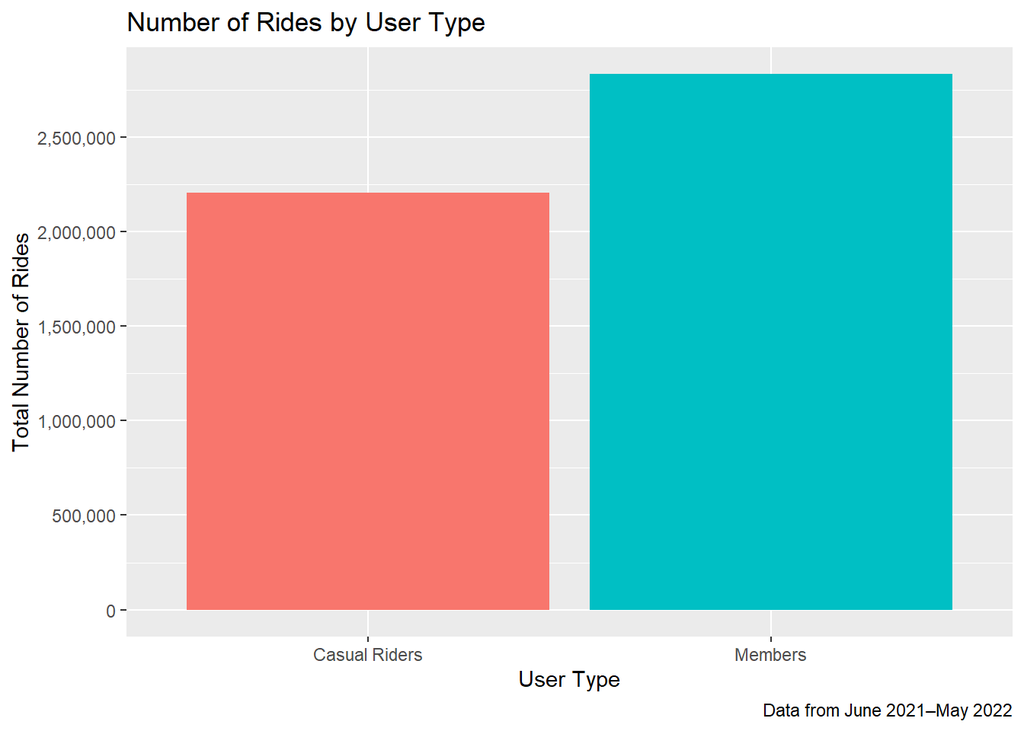

```r
ggplot(rides_by_user_type, aes(x = member_casual, y = ride_count, fill = member_casual)) +
  geom_col(show.legend = FALSE) +
  labs(x = "User Type",
       y = "Total Number of Rides",
       title = "Number of Rides by User Type",
       caption = "Data from June 2021–May 2022") +
  scale_y_continuous(label = comma, breaks = seq(0, 3000000, 500000))
```

**Members go on 29% more rides.**

#### Total ride hours by user type

Calculate total ride hours by user type.

```r
ride_hours_by_user_type <- aggregate(
  all_trips_v2$ride_length ~ all_trips_v2$member_casual, FUN = sum)
```

Simplify column names.

```r
names(ride_hours_by_user_type) <- c("member_casual", "ride_length")
```

Convert ride length from minutes to hours.

```r
ride_hours_by_user_type$ride_length <- ride_hours_by_user_type$ride_length / 60
```

Change the values for members and casual riders to how you want them to appear in the legend.

```r
ride_hours_by_user_type$member_casual[
  ride_hours_by_user_type$member_casual == "member"] <- "Members"

ride_hours_by_user_type$member_casual[
  ride_hours_by_user_type$member_casual == "casual"] <- "Casual Riders"
```

Visualize ride hours by user type.

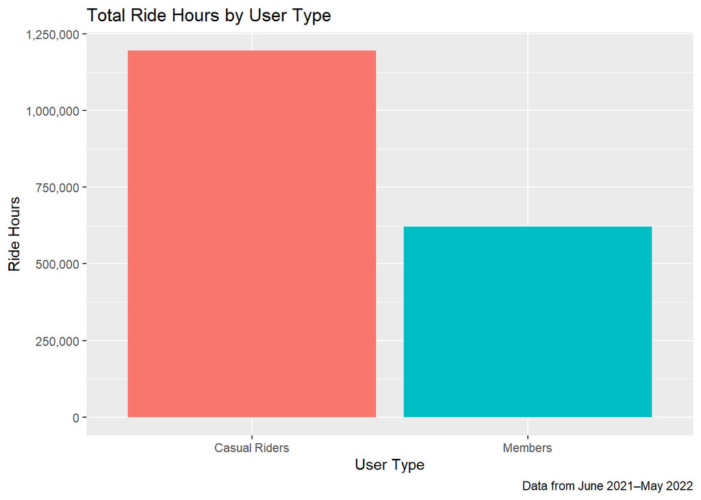

```r
ggplot(ride_hours_by_user_type, aes(
  x = member_casual, y = ride_length, fill = member_casual)) +
  geom_col(show.legend = FALSE) +
  labs(x = "User Type",
       y = "Ride Hours",
       title = "Total Ride Hours by User Type",
       caption = "Data from June 2021–May 2022") +
  scale_y_continuous(label = comma)
```

**However, casual riders spend 92% more time riding.**

### How long are their rides?

#### Average ride length

Calculate average ride length.

```r
avg_ride_length <- aggregate(
  all_trips_v2$ride_length ~ all_trips_v2$member_casual, FUN = mean)
```

Simplify column names.

```r
names(avg_ride_length) <- c("member_casual", "avg_ride_length")
```

Change the values for members and casual riders to show how you want them to appear in the legend.

```r
avg_ride_length$member_casual[
  avg_ride_length$member_casual == "member"] <- "Members"
avg_ride_length$member_casual[
  avg_ride_length$member_casual == "casual"] <- "Casual Riders"
```

Visualize average ride length by user type.

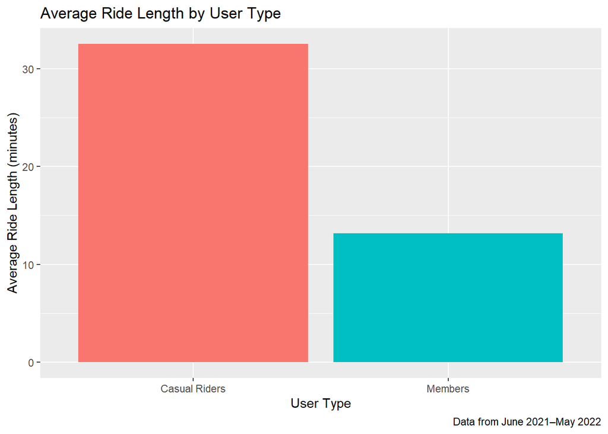

```r
ggplot(avg_ride_length, aes(
  x = member_casual, y = avg_ride_length, fill = member_casual)) +
  geom_col(show.legend = FALSE) +
  labs(x = "User Type",
       y = "Average Ride Length (minutes)",
       title = "Average Ride Length by User Type",
       caption = "Data from June 2021–May 2022")
```

#### Average ride length by day of the week

Calculate average ride length by day of the week.

```r
avg_length_by_weekday <- aggregate(
  all_trips_v2$ride_length ~ all_trips_v2$member_casual +
    all_trips_v2$day_of_week, FUN = mean)
```

Shorten avg_length_by_weekday column names.

```r
names(avg_length_by_weekday) <- c("member_casual", "day_of_week", "ride_length")
```

Change the values for members and casual riders to how you want them to appear in the legend.

```r
avg_length_by_weekday$member_casual[
  avg_length_by_weekday$member_casual == "member"] <- "Members"

avg_length_by_weekday$member_casual[
  avg_length_by_weekday$member_casual == "casual"] <- "Casual Riders"
```

Visualize the data.

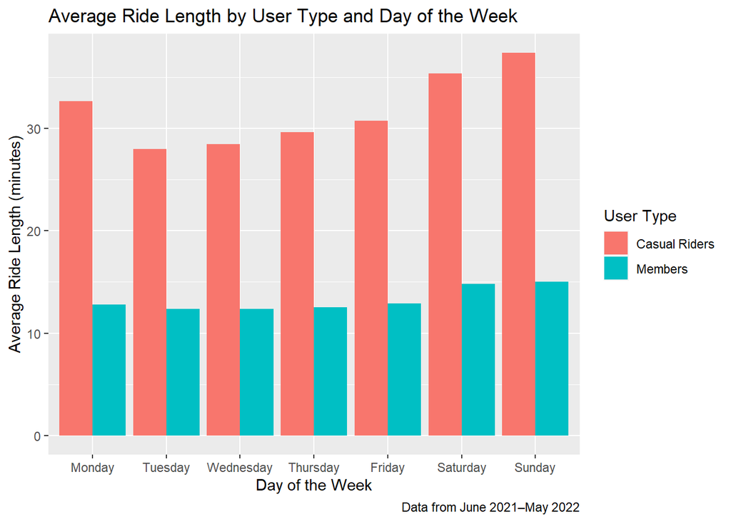

```r
ggplot(avg_length_by_weekday, aes(
  x = day_of_week, y = ride_length, fill = member_casual)) +
  geom_bar(position = "dodge", stat = "identity") +
  labs(x = "Day of the Week",
       y = "Average Ride Length (minutes)",
       fill = "User Type",
       title = "Average Ride Length by User Type and Day of the Week",
       caption = "Data from June 2021–May 2022")
```

#### Average ride length by month

Calculate average ride length by month.

```r
avg_length_by_month <- aggregate(
  all_trips_v2$ride_length ~ all_trips_v2$member_casual +
    all_trips_v2$month, FUN = mean)
```

Simplify column names.

```r
names(avg_length_by_month) <- c("member_casual", "month", "ride_length")
```

Change the values for members and casual riders to how you want them to appear in the legend.

```r
avg_length_by_month$member_casual[
  avg_length_by_month$member_casual == "member"] <- "Members"
avg_length_by_month$member_casual[
  avg_length_by_month$member_casual == "casual"] <- "Casual Riders"
```

Visualize average ride length by month.

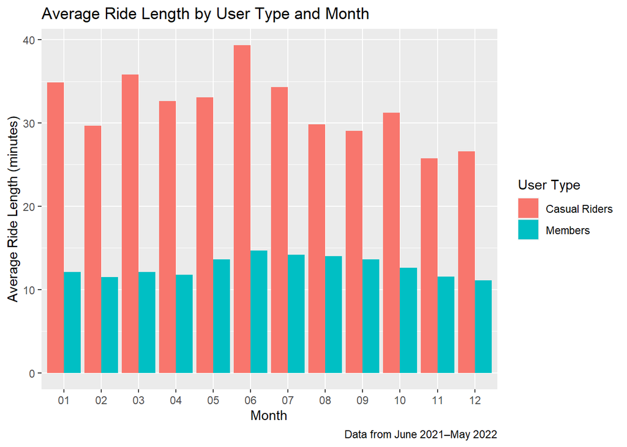

```r
ggplot(avg_length_by_month, aes(
  x = month, y = ride_length, fill = member_casual)) +
  geom_bar(position = "dodge", stat = "identity") +
  labs(x = "Month",
       y = "Average Ride Length (minutes)",
       fill = "User Type",
       title = "Average Ride Length by User Type and Month",
       caption = "Data from June 2021–May 2022")
```

#### Summary

- Members go on more, but shorter, rides.
- Casual riders go on fewer, but longer, rides.
- Casual riders spend more overall time riding.

#### Recommendation

Offer membership deals to people who go on longer rides.

### When do they ride most?

#### Rides by day

Calculate number of rides by day of the week.

```r
rides_by_day <- aggregate(all_trips_v2$ride_id ~ all_trips_v2$member_casual +
                            all_trips_v2$day_of_week, FUN = length)
```

Simplify column names.

```r
names(rides_by_day) <- c("member_casual", "day_of_week", "ride_count")
```

Change the values for members and casual riders to how you want them to appear in the legend.

```r
rides_by_day$member_casual[rides_by_day$member_casual == "member"] <- "Members"
rides_by_day$member_casual[
  rides_by_day$member_casual == "casual"] <- "Casual Riders"
```

Visualize the number of rides by user type by day of the week.

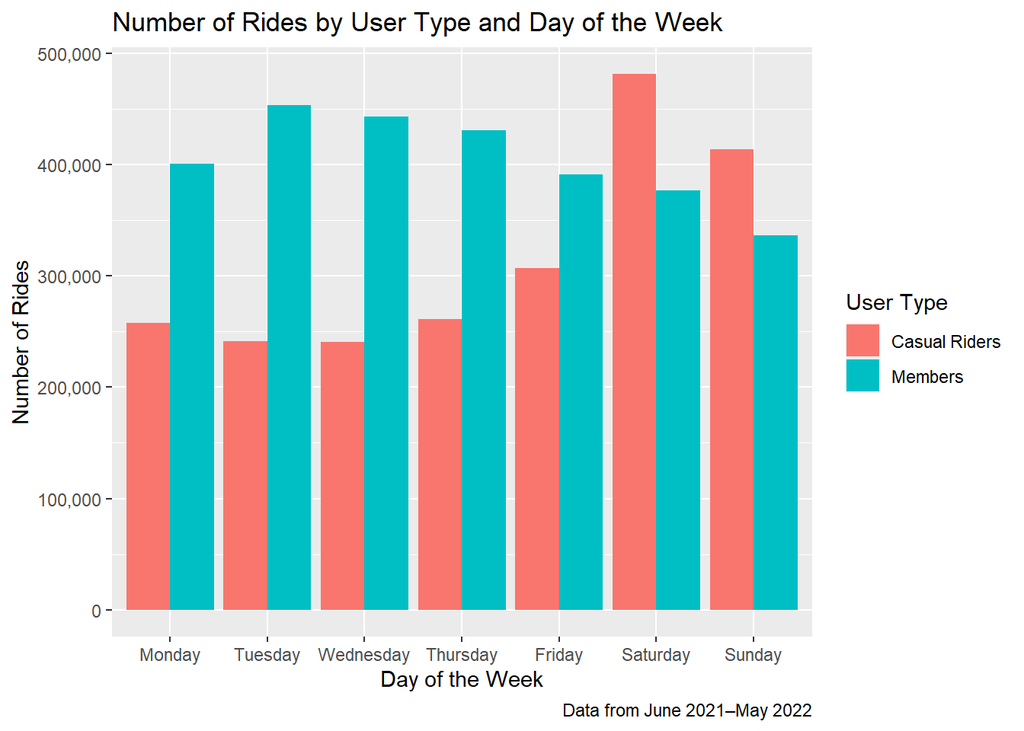

```r
ggplot(rides_by_day, aes(
  x = day_of_week, y = ride_count, fill = member_casual)) +
  geom_bar(position = "dodge", stat = "identity") +
  labs(x = "Day of the Week",
       y = "Number of Rides",
       fill = "User Type",
       title = "Number of Rides by User Type and Day of the Week",
       caption = "Data from June 2021–May 2022") +
  scale_y_continuous(label = comma)
```

#### Ride time by day

Calculate total ride hours by day of the week.

```r
ride_hours_by_day <- aggregate(
  all_trips_v2$ride_length ~ all_trips_v2$member_casual +
    all_trips_v2$day_of_week, FUN = sum)
```

Simplify column names.

```r
names(ride_hours_by_day) <- c("member_casual", "day_of_week", "ride_length")
```

Calculate the ride time in a day as a percentage of ride time in a week.

```r
ride_hours_by_day$user_type_total[
  ride_hours_by_day$member_casual == "member"] <- sum(
    ride_hours_by_day$ride_length[
      ride_hours_by_day$member_casual == "member"])

ride_hours_by_day$user_type_total[
  ride_hours_by_day$member_casual == "casual"] <- sum(
    ride_hours_by_day$ride_length[
      ride_hours_by_day$member_casual == "casual"])

ride_hours_by_day$percentage_of_weekly_total <-
  ride_hours_by_day$ride_length / ride_hours_by_day$user_type_total
```

Change the values for members and casual riders to how you want them to appear in the legend.

```r
ride_hours_by_day$member_casual[
  rides_by_day$member_casual == "member"] <- "Members"
ride_hours_by_day$member_casual[
  ride_hours_by_day$member_casual == "casual"] <- "Casual Riders"
```

Visualize the data.

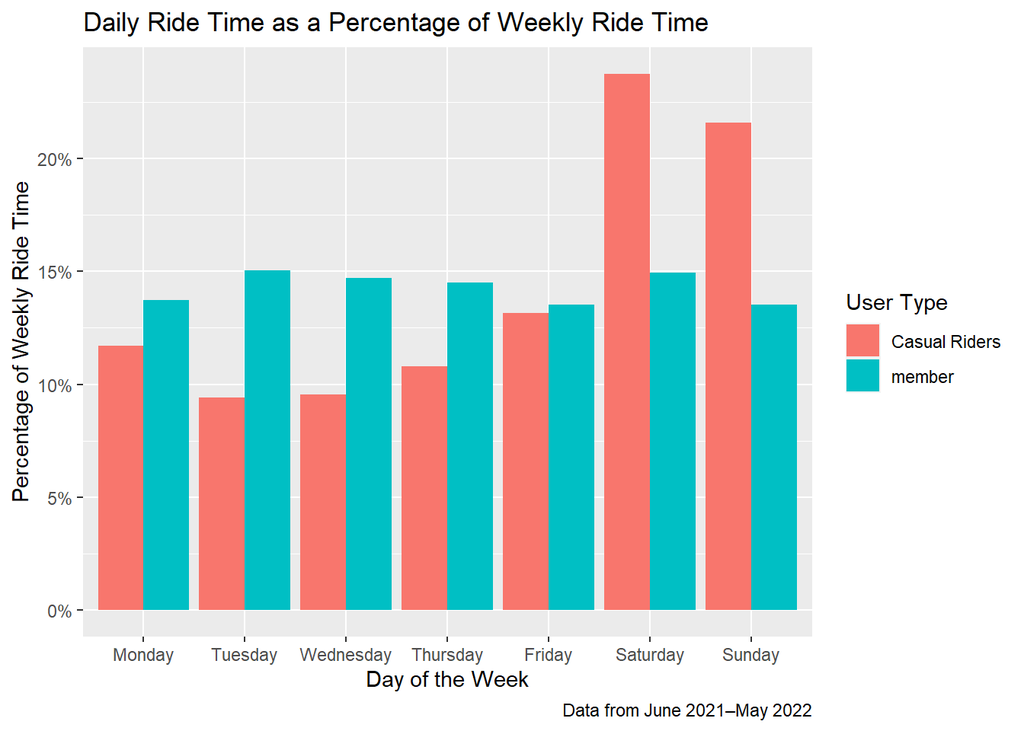

```r
ggplot(ride_hours_by_day, aes(
  x = day_of_week, y = percentage_of_weekly_total, fill = member_casual)) +
  geom_bar(position = "dodge", stat = "identity") +
  labs(x = "Day of the Week",
       y = "Percentage of Weekly Ride Time",
       fill = "User Type",
       title = "Daily Ride Time as a Percentage of Weekly Ride Time",
       caption = "Data from June 2021–May 2022") +
  scale_y_continuous(label = percent)
```

#### Rides by month

Calculate number of rides by month.

```r
rides_by_month <- aggregate(all_trips_v2$ride_id ~ all_trips_v2$member_casual +
                              all_trips_v2$month, FUN = length)
```

Simplify column names.

```r
names(rides_by_month) <- c("member_casual", "month", "ride_count")
```

Change the values for members and casual riders to how you want them to appear in the legend.

```r
rides_by_month$member_casual[
  rides_by_month$member_casual == "member"] <- "Members"
rides_by_month$member_casual[
  rides_by_month$member_casual == "casual"] <- "Casual Riders"
```

Replace month numbers with names and order them.

```r
rides_by_month$month[rides_by_month$month == "06"] <- "Jun-21"
rides_by_month$month[rides_by_month$month == "07"] <- "Jul-21"
rides_by_month$month[rides_by_month$month == "08"] <- "Aug-21"
rides_by_month$month[rides_by_month$month == "09"] <- "Sep-21"
rides_by_month$month[rides_by_month$month == "10"] <- "Oct-21"
rides_by_month$month[rides_by_month$month == "11"] <- "Nov-21"
rides_by_month$month[rides_by_month$month == "12"] <- "Dec-21"
rides_by_month$month[rides_by_month$month == "01"] <- "Jan-22"
rides_by_month$month[rides_by_month$month == "02"] <- "Feb-22"
rides_by_month$month[rides_by_month$month == "03"] <- "Mar-22"
rides_by_month$month[rides_by_month$month == "04"] <- "Apr-22"
rides_by_month$month[rides_by_month$month == "05"] <- "May-22"
rides_by_month$month <- ordered(rides_by_month$month, levels = c(
  "Jun-21", "Jul-21", "Aug-21", "Sep-21", "Oct-21", "Nov-21", "Dec-21",
  "Jan-22", "Feb-22", "Mar-22", "Apr-22", "May-22"))
```

Visualize the number of rides by user type by month.

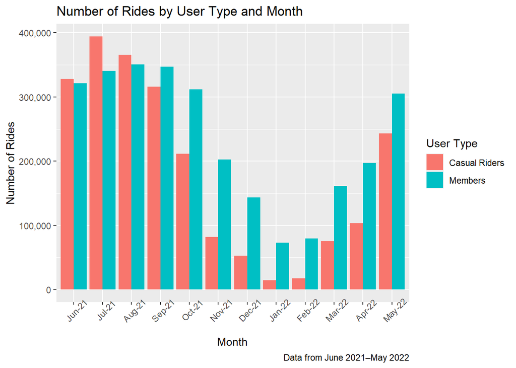

```r
ggplot(rides_by_month, aes(
  x = month, y = ride_count, fill = member_casual)) +
  geom_bar(position = "dodge", stat = "identity") +
  labs(x = "Month",
       y = "Number of Rides",
       fill = "User Type",
       title = "Number of Rides by User Type and Month",
       caption = "Data from June 2021–May 2022") +
  theme(axis.text.x = element_text(angle = 45)) +
  scale_y_continuous(label = comma)
```

#### Ride time by month

Calculate total ride hours by month.

```r
ride_hours_by_month <- aggregate(
  all_trips_v2$ride_length ~ all_trips_v2$member_casual +
    all_trips_v2$month, FUN = sum)
```

Simplify column names.

```r
names(ride_hours_by_month) <- c("member_casual", "month", "ride_length")
```

Calculate the ride time in a month as a percentage of ride time in a year.

```r
ride_hours_by_month$user_type_total[
  ride_hours_by_month$member_casual == "member"] <- sum(
    ride_hours_by_month$ride_length[
      ride_hours_by_month$member_casual == "member"])

ride_hours_by_month$user_type_total[
  ride_hours_by_month$member_casual == "casual"] <- sum(
    ride_hours_by_month$ride_length[
      ride_hours_by_month$member_casual == "casual"])

ride_hours_by_month$percentage_of_annual_total <-
  ride_hours_by_month$ride_length / ride_hours_by_month$user_type_total
```

Change the values for members and casual riders to how you want them to appear in the legend.

```r
ride_hours_by_month$member_casual[
  ride_hours_by_month$member_casual == "member"] <- "Members"

ride_hours_by_month$member_casual[
  ride_hours_by_month$member_casual == "casual"] <- "Casual Riders"
```

Replace month numbers with names and order them.

```r
ride_hours_by_month$month[ride_hours_by_month$month == "06"] <- "Jun-21"
ride_hours_by_month$month[ride_hours_by_month$month == "07"] <- "Jul-21"
ride_hours_by_month$month[ride_hours_by_month$month == "08"] <- "Aug-21"
ride_hours_by_month$month[ride_hours_by_month$month == "09"] <- "Sep-21"
ride_hours_by_month$month[ride_hours_by_month$month == "10"] <- "Oct-21"
ride_hours_by_month$month[ride_hours_by_month$month == "11"] <- "Nov-21"
ride_hours_by_month$month[ride_hours_by_month$month == "12"] <- "Dec-21"
ride_hours_by_month$month[ride_hours_by_month$month == "01"] <- "Jan-22"
ride_hours_by_month$month[ride_hours_by_month$month == "02"] <- "Feb-22"
ride_hours_by_month$month[ride_hours_by_month$month == "03"] <- "Mar-22"
ride_hours_by_month$month[ride_hours_by_month$month == "04"] <- "Apr-22"
ride_hours_by_month$month[ride_hours_by_month$month == "05"] <- "May-22"
ride_hours_by_month$month <- ordered(ride_hours_by_month$month, levels = c(
  "Jun-21", "Jul-21", "Aug-21", "Sep-21", "Oct-21", "Nov-21", "Dec-21",
  "Jan-22", "Feb-22", "Mar-22", "Apr-22", "May-22"))
```

Visualize the data.

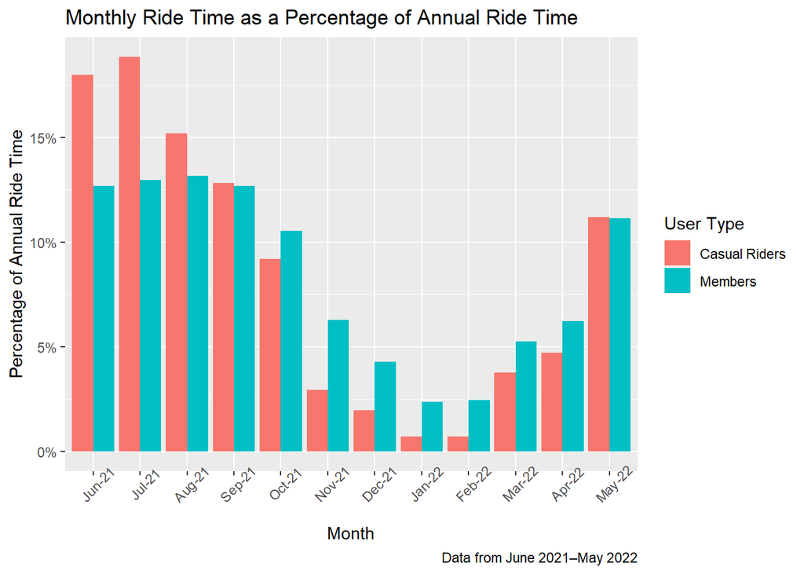

```r
ggplot(ride_hours_by_month, aes(
  x = month, y = percentage_of_annual_total, fill = member_casual)) +
  geom_bar(position = "dodge", stat = "identity") +
  labs(x = "Month",
       y = "Percentage of Annual Ride Time",
       fill = "User Type",
       title = "Monthly Ride Time as a Percentage of Annual Ride Time",
       caption = "Data from June 2021–May 2022") +
  theme(axis.text.x = element_text(angle = 45)) +
  scale_y_continuous(label = percent)
```

#### Summary

- Members ride similar amounts every day of the week.
- Casual riders are much more active on weekends.
- Members have a longer peak activity window (6 months) than casual riders (3–4 months).

#### Recommendation

Focus casual rider-targeted advertising efforts on weekends and summer.

### Where do they ride?

#### Average starting points

Calculate the average starting point for each user type and the distance between them.

```r
# https://statisticsglobe.com/geospatial-distance-between-two-points-in-r
# https://www.datasciencemadesimple.com/mean-function-in-r/
# Average starting latitude among casual riders
avg_start_lat_casual <- mean(
  all_trips_v2$start_lat[all_trips_v2$member_casual == "casual"], na.rm = TRUE)
# Average starting longitude among casual riders
avg_start_lng_casual <- mean(
  all_trips_v2$start_lng[all_trips_v2$member_casual == "casual"], na.rm = TRUE)
# Average starting latitude among members
avg_start_lat_member <- mean(
  all_trips_v2$start_lat[all_trips_v2$member_casual == "member"], na.rm = TRUE)
# Average starting longitude among members
avg_start_lng_member <- mean(
  all_trips_v2$start_lng[all_trips_v2$member_casual == "member"], na.rm = TRUE)

# Create matrix of starting coordinates.
avg_start_coordinates <- matrix(c(avg_start_lng_casual, avg_start_lng_member,
                                  avg_start_lat_casual, avg_start_lat_member),
                                nrow = 2)
colnames(avg_start_coordinates) <- c("longitude", "latitude")
rownames(avg_start_coordinates) <- c("avg_casual_start", "avg_member_start")

# Calculate the rough distance in meters between starting coordinates.
start_dist_betw <- round(distHaversine(avg_start_coordinates), digits = 0)

# Print the difference in average starting points.
# https://r-lang.com/print-in-r/
print(paste("The average starting points for casual riders and members are ",
            start_dist_betw, " meters apart."))
```

```
## [1] "The average starting points for casual riders and members are  183  meters apart."
```

#### Average ending points

Calculate the average ending point for each user type and the distance between them.

```r
# Average ending latitude among casual riders
avg_end_lat_casual <- mean(
  all_trips_v2$end_lat[all_trips_v2$member_casual == "casual"], na.rm = TRUE)
# Average ending longitude among casual riders
avg_end_lng_casual <- mean(
  all_trips_v2$end_lng[all_trips_v2$member_casual == "casual"], na.rm = TRUE)
# Average ending latitude among members
avg_end_lat_member <- mean(
  all_trips_v2$end_lat[all_trips_v2$member_casual == "member"], na.rm = TRUE)
# Average ending longitude among members
avg_end_lng_member <- mean(
  all_trips_v2$end_lng[all_trips_v2$member_casual == "member"], na.rm = TRUE)

# Create matrix of ending coordinates.
avg_end_coordinates <- matrix(c(avg_end_lng_casual, avg_end_lng_member,
                                avg_end_lat_casual, avg_end_lat_member),
                              nrow = 2)
colnames(avg_end_coordinates) <- c("longitude", "latitude")
rownames(avg_end_coordinates) <- c("avg_casual_start", "avg_member_start")

# Calculate the rough distance in meters between ending coordinates.
end_dist_betw <- round(distHaversine(avg_end_coordinates), digits = 0)

# Print the differences in average ending points.
print(paste("The average ending points for casual riders and members are ",
            end_dist_betw, " meters apart."))
```

```
## [1] "The average ending points for casual riders and members are  190  meters apart."
```

#### Most common start stations

```r
start_station_use <- aggregate(
  all_trips_v2$ride_id ~ all_trips_v2$member_casual +
    all_trips_v2$start_station_name, FUN = length)
```

Simplify column names.

```r
names(start_station_use) <- c("member_casual", "start_station_name", "ride_count")
```

Widen the table to have only one row per start station, but separate columns for casual rider and member ride counts.

```r
start_station_use <- start_station_use %>%
  group_by(start_station_name) %>%
  summarize(casual_ride_count = sum(
    ride_count[start_station_use$member_casual == "casual"], na.rm = TRUE),
    member_ride_count = sum(
      ride_count[start_station_use$member_casual == "member"], na.rm = TRUE))
```

Weed out stations with under 100 rides by casual riders or members.

```r
start_station_use <- start_station_use[(
  start_station_use$casual_ride_count >= 100 &
    start_station_use$member_ride_count >= 100),]
```

Produce a list of the most used stations among casual riders.

```r
# https://www.tutorialspoint.com/how-to-remove-a-column-from-an-r-data-frame
top_casual_start_stations <- subset(
  start_station_use, select = -member_ride_count) %>%
  arrange(desc(casual_ride_count))
# Limit top_casual_start_stations to the first 10 rows.
top_casual_start_stations <- top_casual_start_stations[1:10, ]
# Simplify column names.
names(top_casual_start_stations) <-
        c("Casual Start Station", "Rides by Casual Riders")
```

Produce a list of the most used stations among members.

```r
top_member_start_stations <- subset(
  start_station_use, select = -casual_ride_count) %>%
  arrange(desc(member_ride_count))
# Limit top_member_start_stations to the first 10 rows.
top_member_start_stations <- top_member_start_stations[1:10, ]
# Simplify column names.
names(top_member_start_stations) <-
        c("Member Start Station", "Rides by Members")
```

Combine the lists of most used stations.

```r
top_start_stations <-
  data.frame(c(1:10), top_casual_start_stations$`Casual Start Station`,
             top_casual_start_stations$`Rides by Casual Riders`,
             top_member_start_stations$`Member Start Station`,
             top_member_start_stations$`Rides by Members`)
# Simplify column names.
names(top_start_stations) <-
  c("Rank", "Casual Start Station", "Rides by Casual Riders",
    "Member Start Station", "Rides by Members")
top_start_stations
```

```
##    Rank     Casual Start Station Rides by Casual Riders
## 1     1 Kingsbury St & Kinzie St                  26127
## 2     2        Clark St & Elm St                  24889
## 3     3    Wells St & Concord Ln                  24249
## 4     4        Wells St & Elm St                  21159
## 5     5      Ellis Ave & 60th St                  19448
## 6     6    Dearborn St & Erie St                  19342
## 7     7      Wells St & Huron St                  19212
## 8     8  Clinton St & Madison St                  19202
## 9     9   St. Clair St & Erie St                  18780
## 10   10 University Ave & 57th St                  18595
##                  Member Start Station Rides by Members
## 1             Streeter Dr & Grand Ave            67396
## 2                     Millennium Park            31955
## 3               Michigan Ave & Oak St            29226
## 4   DuSable Lake Shore Dr & Monroe St            24191
## 5                      Shedd Aquarium            22868
## 6                 Theater on the Lake            20891
## 7               Wells St & Concord Ln            19830
## 8  DuSable Lake Shore Dr & North Blvd            19516
## 9              Clark St & Lincoln Ave            16699
## 10                  Wells St & Elm St            16397
```

```r
kable(top_start_stations, caption = "Top 10 Start Stations by User Type")
```

Top 10 Start Stations by User Type

| Rank | Casual Start Station | Rides by Casual Riders | Member Start Station | Rides by Members |
| --- | --- | --- | --- | --- |
| 1 | Kingsbury St & Kinzie St | 26127 | Streeter Dr & Grand Ave | 67396 |
| 2 | Clark St & Elm St | 24889 | Millennium Park | 31955 |
| 3 | Wells St & Concord Ln | 24249 | Michigan Ave & Oak St | 29226 |
| 4 | Wells St & Elm St | 21159 | DuSable Lake Shore Dr & Monroe St | 24191 |
| 5 | Ellis Ave & 60th St | 19448 | Shedd Aquarium | 22868 |
| 6 | Dearborn St & Erie St | 19342 | Theater on the Lake | 20891 |
| 7 | Wells St & Huron St | 19212 | Wells St & Concord Ln | 19830 |
| 8 | Clinton St & Madison St | 19202 | DuSable Lake Shore Dr & North Blvd | 19516 |
| 9 | St. Clair St & Erie St | 18780 | Clark St & Lincoln Ave | 16699 |
| 10 | University Ave & 57th St | 18595 | Wells St & Elm St | 16397 |

#### Most common end stations

```r
end_station_use <- aggregate(
  all_trips_v2$ride_id ~ all_trips_v2$member_casual +
    all_trips_v2$end_station_name, FUN = length)
```

Simplify column names.

```r
names(end_station_use) <- c("member_casual", "end_station_name", "ride_count")
```

Widen the table to have only one row per end station, but separate columns for casual rider and member ride counts.

```r
end_station_use <- end_station_use %>%
  group_by(end_station_name) %>%
  summarize(casual_ride_count = sum(
    ride_count[end_station_use$member_casual == "casual"], na.rm = TRUE),
    member_ride_count = sum(
      ride_count[end_station_use$member_casual == "member"], na.rm = TRUE))
```

Weed out stations with under 100 rides by casual riders or members.

```r
end_station_use <- end_station_use[(
  end_station_use$casual_ride_count >= 100 &
    end_station_use$member_ride_count >= 100),]
```

Produce a list of the most used stations among casual riders.

```r
# https://www.tutorialspoint.com/how-to-remove-a-column-from-an-r-data-frame
top_casual_end_stations <- subset(
  end_station_use, select = -member_ride_count) %>%
  arrange(desc(casual_ride_count))
# Limit top_casual_end_stations to the first 10 rows.
top_casual_end_stations <- top_casual_end_stations[1:10, ]
# Simplify column names.
names(top_casual_end_stations) <-
        c("Casual End Station", "Rides by Casual Riders")
```

Produce a list of the most used stations among members.

```r
top_member_end_stations <- subset(
  end_station_use, select = -casual_ride_count) %>%
  arrange(desc(member_ride_count))
# Limit top_member_end_stations to the first 10 rows.
top_member_end_stations <- top_member_end_stations[1:10, ]
# Simplify column names.
names(top_member_end_stations) <-
        c("Member End Station", "Rides by Members")
```

Combine the lists of most used stations.

```r
top_end_stations <-
  data.frame(c(1:10), top_casual_end_stations$`Casual End Station`,
             top_casual_end_stations$`Rides by Casual Riders`,
             top_member_end_stations$`Member End Station`,
             top_member_end_stations$`Rides by Members`)
# Simplify column names.
names(top_end_stations) <-
  c("Rank", "Casual End Station", "Rides by Casual Riders",
    "Member End Station", "Rides by Members")
top_end_stations
```

```
##    Rank                 Casual End Station Rides by Casual Riders
## 1     1            Streeter Dr & Grand Ave                  68238
## 2     2                    Millennium Park                  31877
## 3     3              Michigan Ave & Oak St                  29789
## 4     4 DuSable Lake Shore Dr & North Blvd                  21907
## 5     5  DuSable Lake Shore Dr & Monroe St                  21699
## 6     6                Theater on the Lake                  21558
## 7     7                     Shedd Aquarium                  21096
## 8     8              Wells St & Concord Ln                  18316
## 9     9             Clark St & Lincoln Ave                  15966
## 10   10             Wabash Ave & Grand Ave                  15596
##              Member End Station Rides by Members
## 1      Kingsbury St & Kinzie St            25057
## 2             Clark St & Elm St            23785
## 3         Wells St & Concord Ln            23658
## 4             Wells St & Elm St            20728
## 5       Clinton St & Madison St            19005
## 6         Dearborn St & Erie St            18895
## 7  Clinton St & Washington Blvd            18597
## 8           Wells St & Huron St            18037
## 9        St. Clair St & Erie St            17949
## 10         Broadway & Barry Ave            17479
```

Top 10 End Stations by User Type

```r
kable(top_end_stations, caption = "Top 10 End Stations by User Type")
```

Top 10 End Stations by User Type

| Rank | Casual End Station | Rides by Casual Riders | Member End Station | Rides by Members |
| --- | --- | --- | --- | --- |
| 1 | Streeter Dr & Grand Ave | 68238 | Kingsbury St & Kinzie St | 25057 |
| 2 | Millennium Park | 31877 | Clark St & Elm St | 23785 |
| 3 | Michigan Ave & Oak St | 29789 | Wells St & Concord Ln | 23658 |
| 4 | DuSable Lake Shore Dr & North Blvd | 21907 | Wells St & Elm St | 20728 |
| 5 | DuSable Lake Shore Dr & Monroe St | 21699 | Clinton St & Madison St | 19005 |
| 6 | Theater on the Lake | 21558 | Dearborn St & Erie St | 18895 |
| 7 | Shedd Aquarium | 21096 | Clinton St & Washington Blvd | 18597 |
| 8 | Wells St & Concord Ln | 18316 | Wells St & Huron St | 18037 |
| 9 | Clark St & Lincoln Ave | 15966 | St. Clair St & Erie St | 17949 |
| 10 | Wabash Ave & Grand Ave | 15596 | Broadway & Barry Ave | 17479 |

#### Most common start stations for casual riders relative to members

Add a column dividing the number of rides by casual riders by the number of rides by members.

```r
start_station_use$casual_div_member <-
  start_station_use$casual_ride_count / start_station_use$member_ride_count
```

Sort the table, limit to the first 10 rows, and remove less relevant columns.

```r
relative_start_station_use <- subset(
  start_station_use, select = -casual_ride_count)
relative_start_station_use <- subset(
  relative_start_station_use, select = -member_ride_count)
relative_start_station_use <- arrange(
  relative_start_station_use, desc(casual_div_member))
# Rename the columns for display
names(relative_start_station_use) <- c(
  "Start Station", "Casual Rides ÷ Member Rides")
# Limit to only the top 10 rows.
relative_start_station_use <- relative_start_station_use[1:10, ]
```

```r
kable(relative_start_station_use, caption =
        "Most Common Start Stations for Casual Riders Relative to Members")
```

Most Common Start Stations for Casual Riders Relative to Members

| Start Station | Casual Rides ÷ Member Rides |
| --- | --- |
| State St & 33rd St | 6.386286 |
| Wood St & Taylor St (Temp) | 5.826886 |
| Wolcott Ave & Polk St | 5.741401 |
| Calumet Ave & 33rd St | 5.608441 |
| Loomis St & Lexington St | 5.473811 |
| Morgan St & Polk St | 4.896465 |
| Hermitage Ave & Polk St | 4.673684 |
| Paulina St & Flournoy St | 4.363870 |
| Shields Ave & 31st St | 4.258064 |
| Halsted St & Polk St | 4.192378 |

#### Most common end stations for casual riders relative to members

Add a column dividing the number of rides by casual riders by the number of rides by members.

```r
end_station_use$casual_div_member <-
  end_station_use$casual_ride_count / end_station_use$member_ride_count
```

Sort the table, limit to the first 10 rows, and remove less relevant columns.

```r
relative_end_station_use <- subset(
  end_station_use, select = -casual_ride_count)
relative_end_station_use <- subset(
  relative_end_station_use, select = -member_ride_count)
relative_end_station_use <- arrange(
  relative_end_station_use, desc(casual_div_member))
# Rename the columns for display
names(relative_end_station_use) <- c(
  "End Station", "Casual Rides ÷ Member Rides")
# Limit to only the top 10 rows.
relative_end_station_use <- relative_end_station_use[1:10, ]
```

Most Common End Stations for Casual Riders Relative to Members

```r
kable(relative_end_station_use, caption =
        "Most Common End Stations for Casual Riders Relative to Members")
```

Most Common End Stations for Casual Riders Relative to Members

| End Station | Casual Rides ÷ Member Rides |
| --- | --- |
| Buckingham Fountain | 5.279911 |
| Streeter Dr & Grand Ave | 4.615666 |
| Shedd Aquarium | 4.059265 |
| Millennium Park | 3.769303 |
| Eberhart Ave & 61st St | 3.566038 |
| McCormick Place | 3.285328 |
| Dorchester Ave & 63rd St | 3.265625 |
| Central Park Ave & North Ave | 3.244525 |
| Lake Shore Dr & Monroe St | 3.214104 |
| Field Museum | 3.041572 |

#### Summary

- The differences between casual riders and members in average starting and ending coordinates are relatively small.
- However, there are differences in which stations they frequent.

#### Recommendation

Focus casual rider-targeted advertising on the stations they frequent most.

#### Caution

Some stations most frequented by casual riders may be due to tourists, who are less likely to be local and benefit from membership. It may require further research to determine which stations are most frequented by casual riders who are more likely to benefit from membership.

### Overall Observations and Recommendations

```r
Observation <- c("Casual riders go on fewer, but longer, rides, and spend more overall time riding.",
                  "Casual riders are more likely to ride during weekends and summer.",
                  "Casual riders and members frequent different stations.")
Recommendation <- c("Offer membership deals to people who go on longer rides.",
                     "Focus casual rider-targeted advertising efforts on these times.",
                     "Focus casual rider-targeted advertising on the stations they frequent most, but use caution in tourist-heavy areas where casual riders are less likely to be local.")
observations_and_recommendations <- data.frame(Observation, Recommendation)
```

```r
kable(observations_and_recommendations)
```

| Observation | Recommendation |
| --- | --- |
| Casual riders go on fewer, but longer, rides, and spend more overall time riding. | Offer membership deals to people who go on longer rides. |
| Casual riders are more likely to ride during weekends and summer. | Focus casual rider-targeted advertising efforts on these times. |
| Casual riders and members frequent different stations. | Focus casual rider-targeted advertising on the stations they frequent most, but use caution in tourist-heavy areas where casual riders are less likely to be local. |